# Customer Segmentation - EDA and Scaling

## Importing Necessary Libraries

```python
%load_ext nb_black
import warnings

warnings.filterwarnings("ignore")
# Libraries to help with reading and manipulating data
import numpy as np
import pandas as pd

# Libraries to help with data visualization
import matplotlib.pyplot as plt
import seaborn as sns

# Removes the limit for the number of displayed columns
pd.set_option("display.max_columns", None)
# Sets the limit for the number of displayed rows
pd.set_option("display.max_rows", 200)
# to scale the data using z-score
from sklearn.preprocessing import StandardScaler

# to compute distances
from scipy.spatial.distance import cdist, pdist

# to perform k-means clustering and compute silhouette scores
from sklearn.cluster import KMeans
from sklearn.metrics import silhouette_score

# to visualize the elbow curve and silhouette scores
from yellowbrick.cluster import KElbowVisualizer, SilhouetteVisualizer

# to perform hierarchical clustering, compute cophenetic correlation, and create dendrograms
from sklearn.cluster import AgglomerativeClustering
from scipy.cluster.hierarchy import dendrogram, linkage, cophenet

# to perform PCA
from sklearn.decomposition import PCA
```

## Load and Explore Data

```python
data = pd.read_excel("Credit Card Customer Data.xlsx")
df = data.copy()
print(f"There is {df.shape[0]} rows and {df.shape[1]} columns in the dataset")
np.random.seed(15)
df.sample(10)
```

```
There is 660 rows and 7 columns in the dataset
```

|  | Sl_No | Customer Key | Avg_Credit_Limit | Total_Credit_Cards | Total_visits_bank | Total_visits_online | Total_calls_made |
| --- | --- | --- | --- | --- | --- | --- | --- |
| 210 | 211 | 67212 | 16000 | 4 | 1 | 4 | 6 |
| 512 | 513 | 76492 | 62000 | 6 | 2 | 1 | 3 |
| 459 | 460 | 45341 | 74000 | 7 | 4 | 2 | 4 |
| 638 | 639 | 17538 | 153000 | 8 | 1 | 7 | 1 |
| 508 | 509 | 27117 | 59000 | 7 | 2 | 0 | 3 |
| 396 | 397 | 77954 | 73000 | 6 | 4 | 2 | 0 |
| 568 | 569 | 67282 | 58000 | 6 | 5 | 1 | 0 |
| 457 | 458 | 64774 | 57000 | 5 | 2 | 0 | 4 |
| 103 | 104 | 73007 | 13000 | 1 | 0 | 3 | 7 |
| 241 | 242 | 81878 | 10000 | 4 | 5 | 1 | 3 |

```python
df.info()
```

```
<class 'pandas.core.frame.DataFrame'>
RangeIndex: 660 entries, 0 to 659
Data columns (total 7 columns):
 #   Column               Non-Null Count  Dtype
---  ------               --------------  -----
 0   Sl_No                660 non-null    int64
 1   Customer Key         660 non-null    int64
 2   Avg_Credit_Limit     660 non-null    int64
 3   Total_Credit_Cards   660 non-null    int64
 4   Total_visits_bank    660 non-null    int64
 5   Total_visits_online  660 non-null    int64
 6   Total_calls_made     660 non-null    int64
dtypes: int64(7)
memory usage: 36.2 KB
```

- All 7 columns are of numerical datatype.
- Customer Key represents an unique identification number for each customer.
- There seems to be no missing values in the dataset

**Let's look at the unique values and their counts for each columns**

```python
df.nunique()
```

```
Sl_No                  660
Customer Key           655
Avg_Credit_Limit       110
Total_Credit_Cards      10
Total_visits_bank        6
Total_visits_online     16
Total_calls_made        11
dtype: int64
```

**Observations**

- There are 5 less unique values in `Customer Key`.
- This suggest duplicates. Let's analyse them

```python
duplicate = df.groupby("Customer Key").count()

for i in duplicate.loc[duplicate.Sl_No >= 2].index:
    display(df.loc[df["Customer Key"] == i])
```

|  | Sl_No | Customer Key | Avg_Credit_Limit | Total_Credit_Cards | Total_visits_bank | Total_visits_online | Total_calls_made |
| --- | --- | --- | --- | --- | --- | --- | --- |
| 48 | 49 | 37252 | 6000 | 4 | 0 | 2 | 8 |
| 432 | 433 | 37252 | 59000 | 6 | 2 | 1 | 2 |

|  | Sl_No | Customer Key | Avg_Credit_Limit | Total_Credit_Cards | Total_visits_bank | Total_visits_online | Total_calls_made |
| --- | --- | --- | --- | --- | --- | --- | --- |
| 4 | 5 | 47437 | 100000 | 6 | 0 | 12 | 3 |
| 332 | 333 | 47437 | 17000 | 7 | 3 | 1 | 0 |

|  | Sl_No | Customer Key | Avg_Credit_Limit | Total_Credit_Cards | Total_visits_bank | Total_visits_online | Total_calls_made |
| --- | --- | --- | --- | --- | --- | --- | --- |
| 411 | 412 | 50706 | 44000 | 4 | 5 | 0 | 2 |
| 541 | 542 | 50706 | 60000 | 7 | 5 | 2 | 2 |

|  | Sl_No | Customer Key | Avg_Credit_Limit | Total_Credit_Cards | Total_visits_bank | Total_visits_online | Total_calls_made |
| --- | --- | --- | --- | --- | --- | --- | --- |
| 391 | 392 | 96929 | 13000 | 4 | 5 | 0 | 0 |
| 398 | 399 | 96929 | 67000 | 6 | 2 | 2 | 2 |

|  | Sl_No | Customer Key | Avg_Credit_Limit | Total_Credit_Cards | Total_visits_bank | Total_visits_online | Total_calls_made |
| --- | --- | --- | --- | --- | --- | --- | --- |
| 104 | 105 | 97935 | 17000 | 2 | 1 | 2 | 10 |
| 632 | 633 | 97935 | 187000 | 7 | 1 | 7 | 0 |

- There are 5 duplicate entries for the above Customer Key.
- Since we do not have any further information from the business and by removing the rows, we might lose information.
- Also, the entries look like Customer information updates. Hence we will not be deleting them.

### Missing values Identification and Treatment

```python
df.isna().sum()
```

```
Sl_No                  0
Customer Key           0
Avg_Credit_Limit       0
Total_Credit_Cards     0
Total_visits_bank      0
Total_visits_online    0
Total_calls_made       0
dtype: int64
```

- There are no missing values in this dataset.

**We will drop Sl_No and Customer Key as they dont add any value to our analysis**

```python
df.drop(columns=["Sl_No"], inplace=True)
df.drop(columns=["Customer Key"], inplace=True)
```

**Summary of Numerical Column**

```python
df.describe()
```

|  | Avg_Credit_Limit | Total_Credit_Cards | Total_visits_bank | Total_visits_online | Total_calls_made |
| --- | --- | --- | --- | --- | --- |
| count | 660.000000 | 660.000000 | 660.000000 | 660.000000 | 660.000000 |
| mean | 34574.242424 | 4.706061 | 2.403030 | 2.606061 | 3.583333 |
| std | 37625.487804 | 2.167835 | 1.631813 | 2.935724 | 2.865317 |
| min | 3000.000000 | 1.000000 | 0.000000 | 0.000000 | 0.000000 |
| 25% | 10000.000000 | 3.000000 | 1.000000 | 1.000000 | 1.000000 |
| 50% | 18000.000000 | 5.000000 | 2.000000 | 2.000000 | 3.000000 |
| 75% | 48000.000000 | 6.000000 | 4.000000 | 4.000000 | 5.000000 |
| max | 200000.000000 | 10.000000 | 5.000000 | 15.000000 | 10.000000 |

**Observations:**

- The max value for Avg_Credit_Limit is a high \ $200000. This could be an outlier and needs further checking.
- Total_Credit_Cards ranges between 1-10
- Total_visits_bank has somewhat even distribution, but many customers have not visited the bank
- This trend also follows in Total_visits_online and Total_calls_made

# Exploratory Data Analysis

```python
# Performing Univariate Analysis to study the central tendency and dispersion
# Plotting distplot and boxplot to study distribution
def Uni_num(var, figsize=(9, 9)):
    fig, (ax_box, ax_dis) = plt.subplots(
        2, 1, sharex=True, figsize=figsize, gridspec_kw={"height_ratios": (0.35, 0.65)}
    )

    sns.boxplot(var, ax=ax_box, showmeans=True, color="orange")
    sns.distplot(var, ax=ax_dis, kde=True, color="green")
    ax_dis.axvline(np.mean(var), color="m", linewidth=2, linestyle="--")
    ax_dis.axvline(np.median(var), color="black", linewidth=2, linestyle="--")
```

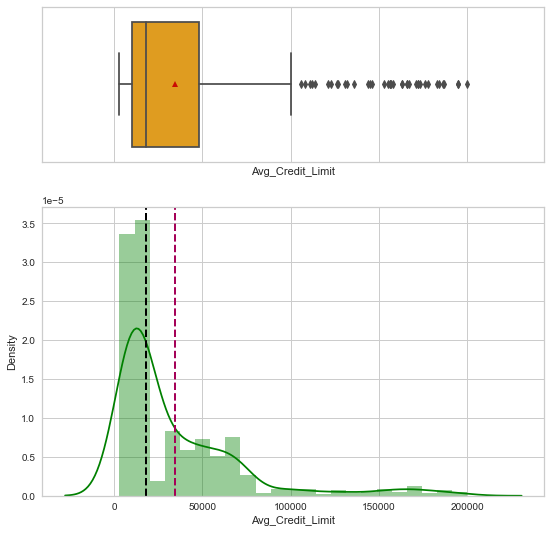

```python
Uni_num(df.Avg_Credit_Limit)
```

**Observations**

- The Average_Credit_Limit is right skewed with several outliers in the higher end.
- The distribution is almost continuous with gaps between the points evently distributed.
- We see that almost 75% of Customers have less than $50,000 in Average credit limit

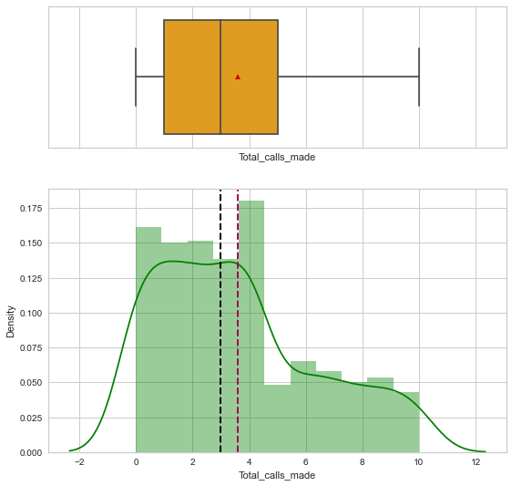

```python
Uni_num(df.Total_calls_made)
```

**Observations**

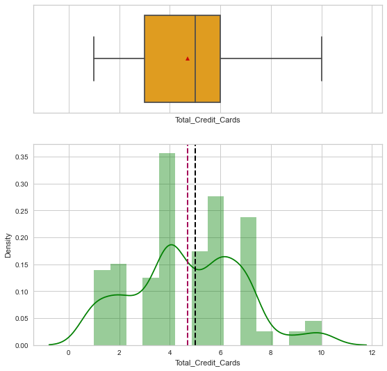

```python
Uni_num(df.Total_Credit_Cards)
```

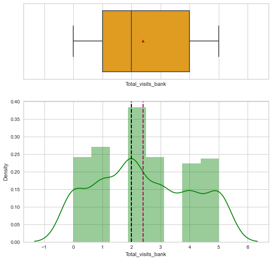

```python
Uni_num(df.Total_visits_bank)
```

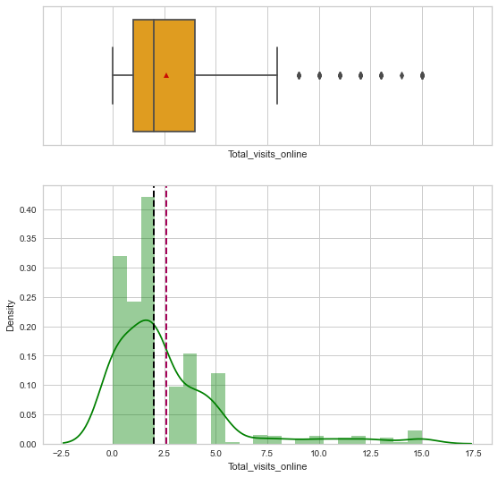

```python
Uni_num(df.Total_visits_online)
```

**Observations:**

**Creating bins for the Average_Credit_Limit column**

```python
df["Credit_Limit_Bin"] = pd.cut(
    df.Avg_Credit_Limit,
    bins=[0, 25500, 50500, 100500, 150500, 200500, 250500],
    labels=["<25000", "<50000", "<100000", "<150000", "<200000", ">200000"],
)
```

```python
def Count_uni(feature, figsize=(10, 7)):

    ax = sns.countplot(feature, palette="Set2")
    plt.xticks(fontsize=13)
    total = len(feature)  # length of the column
    for p in ax.patches:
        percentage = "{:.1f}%".format(
            100 * p.get_height() / total
        )  # percentage of each class of the category
        x = p.get_x() + (p.get_width() / 2) - 0.1  # width of the plot
        y = p.get_y() + p.get_height()  # hieght of the plot
        ax.annotate(
            percentage, (x, y), size=12, color="black"
        )  # To annonate the percentage on the barchart
```

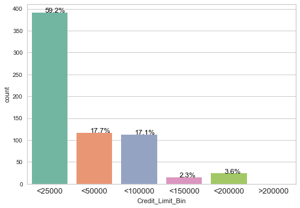

```python
Count_uni(df.Credit_Limit_Bin)
```

**Observations:**

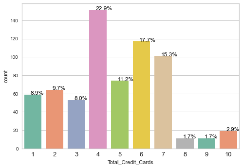

```python
Count_uni(df.Total_Credit_Cards)
```

**Observations**

- Customers with 4 credit cards have the highest percentage at 22.9% and customers with 6 credit cards coming second at 17.7%
- Very few customers seem to have cards greater than 7

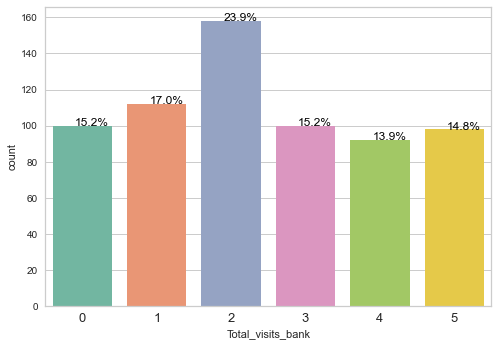

```python
Count_uni(df.Total_visits_bank)
```

**Observations**:

- 15.2% have never visited the bank.

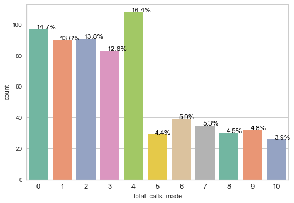

```python
Count_uni(df.Total_calls_made)
```

**Observations**

- 14.7 % have never called the bank for any services.
- Around 4 calls seems to the max number for most customers

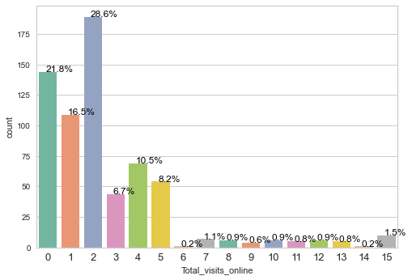

```python
Count_uni(df.Total_visits_online)
```

- Customers who have atleast 6 or higher visits to the bank's online portal comprise only ~ 7%.
- Whereas, around 21.8 % never used the online portal.

### Correlation Matrix

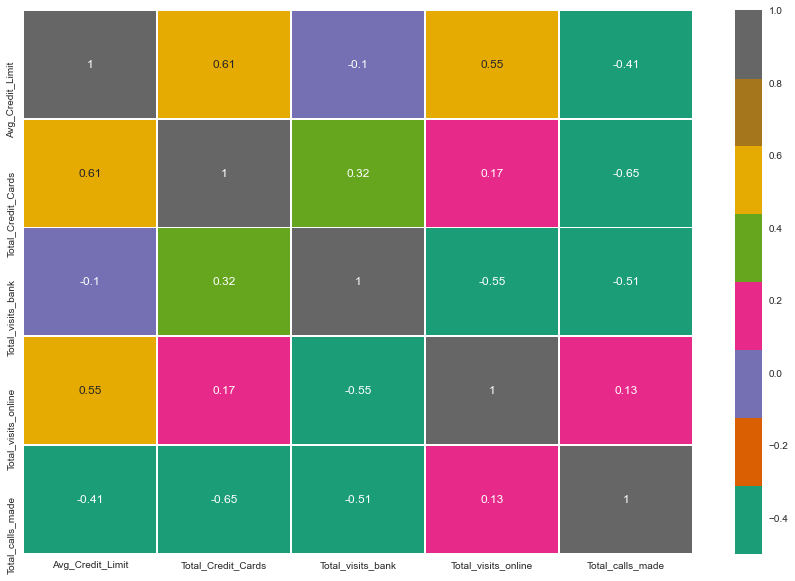

```python
corr = df.corr()
plt.figure(figsize=(15, 10))
sns.heatmap(corr, annot=True, vmin=-0.5, vmax=1, cmap="Dark2", linewidths=0.5)
plt.show()
```

**Observations**

- Avg_Credit_Limit has strong positive correlation with Total_Credit_cards, which is obvious as the credit limit is the average for all the cards owned by the customer
- Avg_Credit_Limit also has a strong positive correlation with Total_Visits_Online.
- Total_calls_made has high negative correlation with Avg_Credit_Limit, Total_Credit_Cards and Total_visits_bank, suggesting a drop in Customers calling the bank.

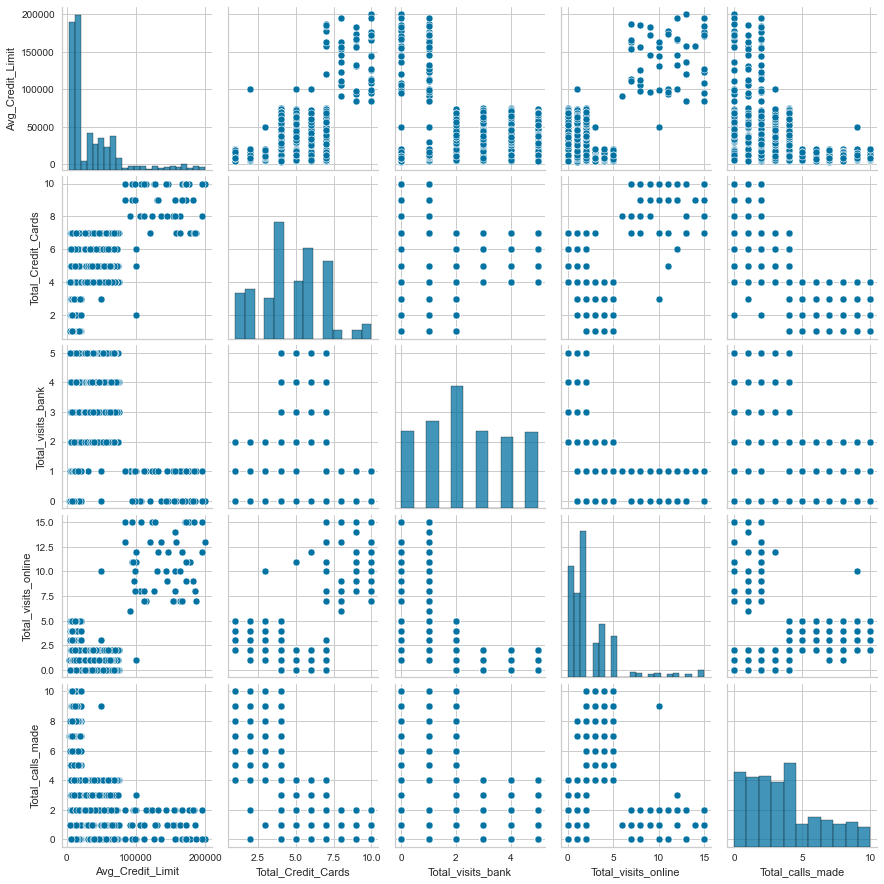

```python
sns.pairplot(data=df, palette="Dark")
```

### Bivariate Analysis:

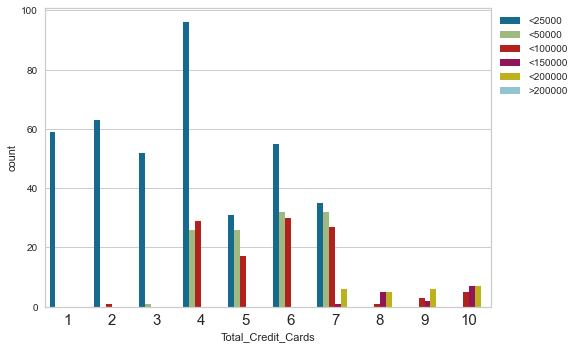

```python
sns.countplot(data=df, x="Total_Credit_Cards", hue="Credit_Limit_Bin")
plt.legend(loc="upper left", bbox_to_anchor=(1, 1))
plt.xticks(fontsize=15)
plt.show()
```

- The positive correlation between Credit card and Credit limit is seen here.
- Customers with more Cards have higher Avg_Credit_Limit

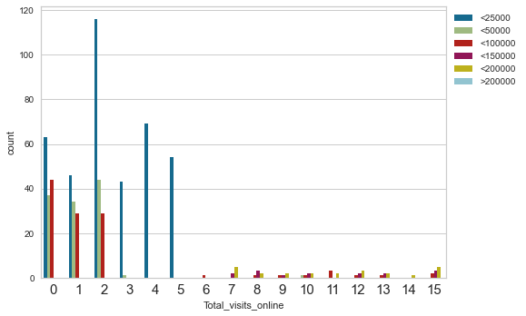

```python
sns.countplot(data=df, x="Total_visits_online", hue="Credit_Limit_Bin")
plt.legend(loc="upper left", bbox_to_anchor=(1, 1))
plt.xticks(fontsize=15)
plt.show()
```

- Customers who Avg_Credit_Limit less than 25000 have lower online visits that customers with Higher credit.

**From the plots above we can see there are almost three segments of clusters forming. Let's analyse further**

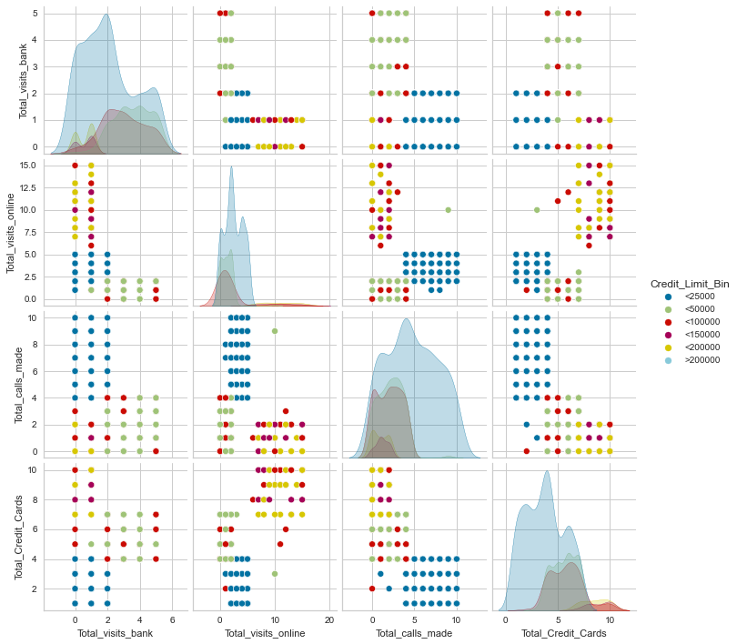

```python
sns.pairplot(
    data=df[
        [
            "Total_visits_bank",
            "Total_visits_online",
            "Total_calls_made",
            "Total_Credit_Cards",
            "Credit_Limit_Bin"
        ]
    ],
    hue="Credit_Limit_Bin",
)
```

**Observation**

### Outlier Detection and Treatment

```python
outlier_num = df.select_dtypes(include=np.number)
Q1 = df.quantile(0.25)  # To find the 25th percentile and 75th percentile.
Q3 = df.quantile(0.75)

IQR = Q3 - Q1  # Inter Quantile Range (75th perentile - 25th percentile)

lower = (
    Q1 - 1.5 * IQR
)  # Finding lower and upper bounds for all values. All values outside these bounds are outliers
upper = Q3 + 1.5 * IQR
```

```python
round(((outlier_num < lower) | (outlier_num > upper)).sum() / len(df) * 100, 3)
```

```
Avg_Credit_Limit       5.909
Total_Credit_Cards     0.000
Total_visits_bank      0.000
Total_visits_online    5.606
Total_calls_made       0.000
dtype: float64
```

- Only Avg_Credit_Limit and Total_visits_online columns have outliers.
- Since both columns are depend on the number of Credit cards owned by the customer, it can represent a separate cluster on its own and hence we will not be treating them.

## Data Pre-Processing:

**Before we proceed, we will scale the data using StandardScaler(). Scaling the data will ensure that the there will be no dominance from columns with larger or higher values. We will only be performing the clustering on the Numerical columns**

```python
Std_sc = StandardScaler()  # the scaling measure
subset = df.drop(["Credit_Limit_Bin"], axis=1)  # removing the Credit Bin column
scaled_subset = Std_sc.fit_transform(subset)
```

```python
df_scaled_subset = pd.DataFrame(scaled_subset, columns=subset.columns)
df_scaled_subset.head()
```

|  | Avg_Credit_Limit | Total_Credit_Cards | Total_visits_bank | Total_visits_online | Total_calls_made |
| --- | --- | --- | --- | --- | --- |
| 0 | 1.740187 | -1.249225 | -0.860451 | -0.547490 | -1.251537 |
| 1 | 0.410293 | -0.787585 | -1.473731 | 2.520519 | 1.891859 |
| 2 | 0.410293 | 1.058973 | -0.860451 | 0.134290 | 0.145528 |
| 3 | -0.121665 | 0.135694 | -0.860451 | -0.547490 | 0.145528 |
| 4 | 1.740187 | 0.597334 | -1.473731 | 3.202298 | -0.203739 |

- The columns are scaled and then converted to dataframe.

## K-means Clustering

```
Number of Clusters: 1 	Average Distortion: 2.0069222262503614
Number of Clusters: 2 	Average Distortion: 1.4571553548514269
Number of Clusters: 3 	Average Distortion: 1.1466276549150365
Number of Clusters: 4 	Average Distortion: 1.0463825294774465
Number of Clusters: 5 	Average Distortion: 0.9908683849620168
Number of Clusters: 6 	Average Distortion: 0.9430843103448057
Number of Clusters: 7 	Average Distortion: 0.922657413871102
Number of Clusters: 8 	Average Distortion: 0.8909309483347856
Number of Clusters: 9 	Average Distortion: 0.8663759336871818
Number of Clusters: 10 	Average Distortion: 0.8409767478311165
```

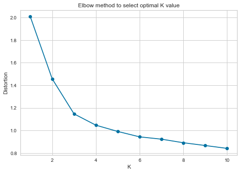

```python
clusters = range(1, 11)  # a range of possible K values
meandistortions = []  # empty list for elbow curve plot

for k in clusters:
    model = KMeans(n_clusters=k)
    model.fit(df_scaled_subset)
    model.predict(df_scaled_subset)
    distortion = (
        sum(
            np.min(cdist(df_scaled_subset, model.cluster_centers_, "euclidean"), axis=1)
        )
        / df_scaled_subset.shape[0]
    )
    meandistortions.append(distortion)
    print("Number of Clusters:", k, "\tAverage Distortion:", distortion)

plt.plot(clusters, meandistortions, "bo-")  # Elbow Curve
plt.xlabel("K")
plt.ylabel("Distortion")
plt.title("Elbow method to select optimal K value")
```

- There is a steady decline in Average Distortion as the value of K increases
- The optimal K value from the elbow curve seems to between 2 or 3.

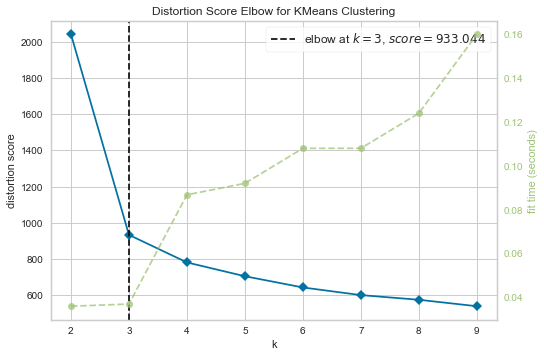

```python
model = KMeans(random_state=1)
visualizer = KElbowVisualizer(model, k=(2, 10), timings=True)
visualizer.fit(df_scaled_subset)  # fit the data to the visualizer
visualizer.show()  # finalize and render figure
```

**Let's check the silhouette scores**

```
For n_cluster =2, the silhouette score is0.41842496663215445
For n_cluster =3, the silhouette score is0.5157182558881063
For n_cluster =4, the silhouette score is0.3556670619372605
For n_cluster =5, the silhouette score is0.2717470361089752
For n_cluster =6, the silhouette score is0.25583657571102003
For n_cluster =7, the silhouette score is0.24857211535274673
For n_cluster =8, the silhouette score is0.22803909808418496
For n_cluster =9, the silhouette score is0.21888559131167867
```

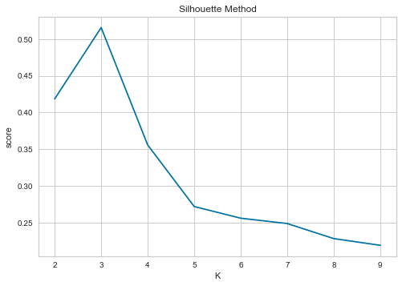

```python
sil_score = []
cluster_list = list(range(2,10))
for n in cluster_list:
    model1 = KMeans(n_clusters=n)
    pred = model1.fit_predict(df_scaled_subset)
    score = silhouette_score(df_scaled_subset,pred)
    sil_score.append(score)
    print('For n_cluster ={}, the silhouette score is{}'.format(n,score))

plt.plot(cluster_list,sil_score)
plt.title('Silhouette Method')
plt.xlabel('K')
plt.ylabel('score')
```

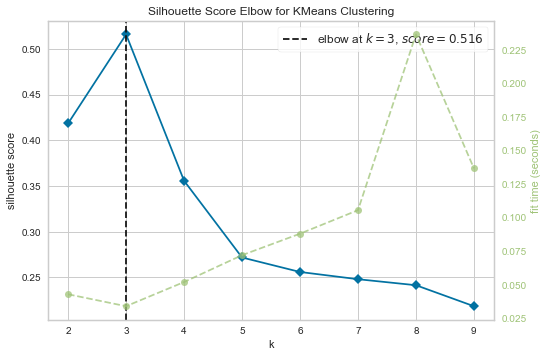

```python
model = KMeans(random_state=1)
visualizer = KElbowVisualizer(model, k=(2, 10), metric="silhouette", timings=True)
visualizer.fit(df_scaled_subset)  # fit the data to the visualizer
visualizer.show()  # finalize and render figure
```

- From the above graphs and Silhouette scores, k=3 seems to be a good vlaue

**Let's plot the Silhouette plot for K values 2,3 and 4 to see the cluster distribution**

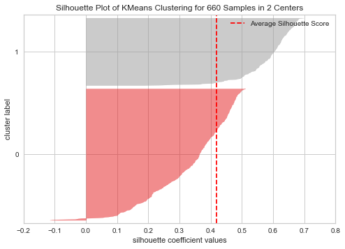

```python
# finding optimal no. of clusters with silhouette coefficients
visualizer = SilhouetteVisualizer(KMeans(2, random_state=15))
visualizer.fit(df_scaled_subset)
visualizer.show()
```

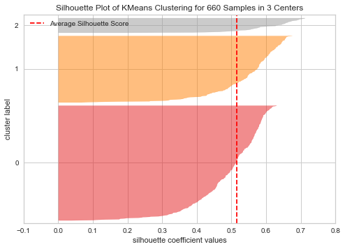

```python
visualizer = SilhouetteVisualizer(KMeans(3, random_state=15))
visualizer.fit(df_scaled_subset)
visualizer.show()
```

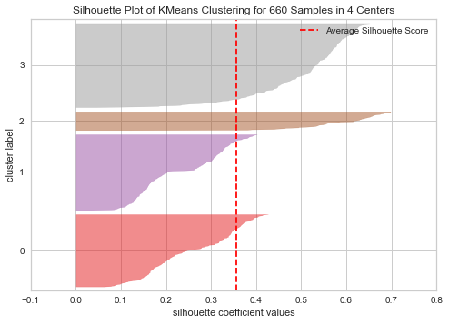

```python
visualizer = SilhouetteVisualizer(KMeans(4, random_state=15))
visualizer.fit(df_scaled_subset)
visualizer.show()
```

**From the above diagrams and also from the EDA, K=3 seems like an appropriate number**

**It has a good cluster distribution and high silhouette score. The distribution is also uniform despite different in magnitudes. Hence we will proceed with 3 clusters using K-means**

```python
kmeans = KMeans(n_clusters=3, random_state=15)
kmeans.fit(df_scaled_subset)
```

```
KMeans(n_clusters=3, random_state=15)
```

```python
# adding the kmeans cluster to original dataset
df1 = df.copy()  # making a copy
df1["KMeans Cluster Segment"] = kmeans.labels_
```

```python
df1.head()
```

|  | Avg_Credit_Limit | Total_Credit_Cards | Total_visits_bank | Total_visits_online | Total_calls_made | Credit_Limit_Bin | KMeans Cluster Segment |
| --- | --- | --- | --- | --- | --- | --- | --- |
| 0 | 100000 | 2 | 1 | 1 | 0 | <100000 | 0 |
| 1 | 50000 | 3 | 0 | 10 | 9 | <50000 | 1 |
| 2 | 50000 | 7 | 1 | 3 | 4 | <50000 | 0 |
| 3 | 30000 | 5 | 1 | 1 | 4 | <50000 | 0 |
| 4 | 100000 | 6 | 0 | 12 | 3 | <100000 | 2 |

- The cluster segments are added to each customers

### Cluster Profiling - KMeans

```python
cluster_profile_kmeans = df1.groupby("KMeans Cluster Segment").mean()
```

```python
# Let's count how many rows are there in each cluster
cluster_profile_kmeans["Total_count_per_segment"] = (
    df1.groupby("KMeans Cluster Segment")["Avg_Credit_Limit"].count().values
)
```

```python
# display the cluster profiles
cluster_profile_kmeans.style.highlight_max(color="lightblue", axis=0)
```

| KMeans Cluster Segment | Avg_Credit_Limit | Total_Credit_Cards | Total_visits_bank | Total_visits_online | Total_calls_made | Total_count_per_segment |
| --- | --- | --- | --- | --- | --- | --- |
| 0 | 33782.383420 | 5.515544 | 3.489637 | 0.981865 | 2.000000 | 386 |
| 1 | 12174.107143 | 2.410714 | 0.933036 | 3.553571 | 6.870536 | 224 |
| 2 | 141040.000000 | 8.740000 | 0.600000 | 10.900000 | 1.080000 | 50 |

**Observations**

- Cluster 0 has the highest number of data at 386 and Cluster 2 has the lowest number of data at only 50.

### K Means Cluster Profile:

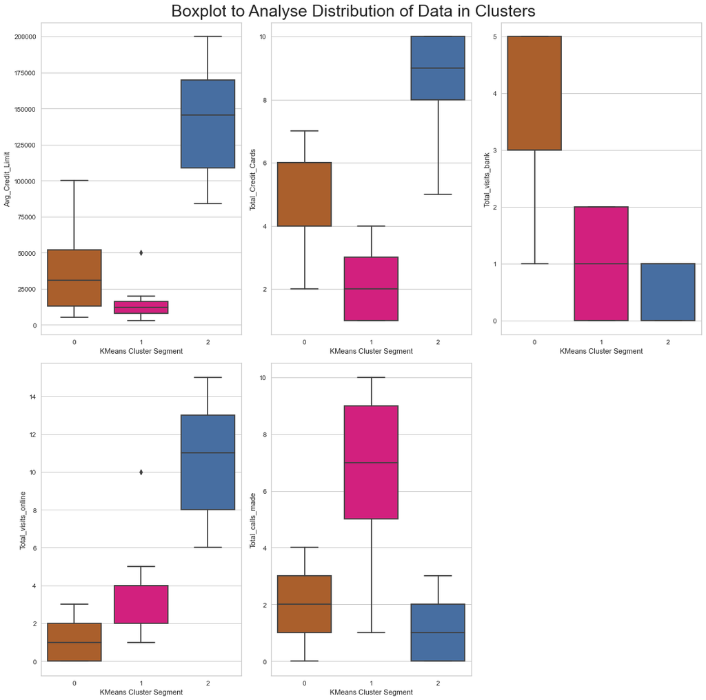

```python
num_col = ['Avg_Credit_Limit',
 'Total_Credit_Cards',
 'Total_visits_bank',
 'Total_visits_online',
 'Total_calls_made']

plt.figure(figsize=(15,15))
plt.suptitle('Boxplot to Analyse Distribution of Data in Clusters',fontsize=25)
sns.set_palette('Accent_r')
for i in range(0,5):
        plt.subplot(2,3,i+1)
        sns.boxplot(x=df1['KMeans Cluster Segment'],y=df1[num_col[i]])
        plt.tight_layout()
```

### Cluster Insights:

**Cluster 0**

- There are 386 Customers in this cluster
- Majority of customers have Avg_Credit_Limit less than \$50000 in this cluseter
- Customers have between 4 to 7 Credit cards
- Total_visists_bank is high
- Total_visits_online is low, between 0 to 3.
- Total_calls_made is moderate between 1 to 4

**Cluster 1**

- There are 224 Customers in this cluster
- The Average_Credit_Limit is very low and less than \$25000, with few outliers in the high end.
- Customers have between 1 to 4 credit cards
- Total_visits_bank is low, between 0-2
- Total_visits_online is at moderate, as most customers visit between 2-4 times
- Total_calls_made is the highest for this cluster, with most customers making between 5 to 9 calls to the bank

**Cluster 2**

- There are only 50 customers in this cluster
- The Average_Credit_Limit for this cluster is higer; at \$80000 and above
- Likewise, most customers have between 8 to 10 credit cards
- Total_vistits_bank is the lowest here between 0 to 1 for almost all customers
- Total_visits_online is high here, with most customers visiting between 8 to 13 times
- Total_calls_made is low, with most customers making less than 2 calls to the bank

**K-Means**

```python
pd.crosstab(df1["KMeans Cluster Segment"], df1["Credit_Limit_Bin"]).style.highlight_max(
    color="lightpink", axis=0
)
```

| Credit_Limit_Bin KMeans Cluster Segment | <25000 | <50000 | <100000 | <150000 | <200000 |
| --- | --- | --- | --- | --- | --- |
| 0 | 168 | 116 | 102 | 0 | 0 |
| 1 | 223 | 1 | 0 | 0 | 0 |
| 2 | 0 | 0 | 11 | 15 | 24 |

**Observations**

- Cluster 2 has captured all customers with credit limit between \$150,000 to \\$200,000 and about 11 in the bin <100000.
- This suggests that Cluster 2 has the higher Credit limit and high Credit Card customers.
- From the table, it suggests that Cluster 0 has the middle range Customers.
- Cluster 1 has maximum lower credit limit customers.